# DATA 607 - Project 2: Data Set 1 (Assignment #4 Resubmission)

Julian Adames-Ng

2024-10-06

# Introduction

When working with data, you should expect to spend a good amount of time in the clean-up process, but it is not always ‘messy’ or unreadable. For example, data can still be organized in a data-frame in a way that is readable, but at the same time it may not be useful in such presented formats. In these cases, we may have to transpose the data-frame and re-organize to fit our needs.

## Loading Data: Creating the Initial Data-Frame

The data is loaded into a data-frame called ‘flights_df’.

```r
rm(list = ls())

flights_df <- data.frame(
  c('ALASKA',NA,NA,'AM WEST',NA),
  c('on time','delayed',NA,'on time','delayed'),
  c(497,62,NA,694,117),
  c(221,12,NA,4840,415),
  c(212,20,NA,383,65),
  c(503,102,NA,320,129),
  c(1841,305,NA,201,61)
)

colnames(flights_df) <- c('','','Los Angeles','Phoenix','San Diego','San Francisco','Seattle')

#view current state of data-frame
flights_df
```

```
##                   Los Angeles Phoenix San Diego San Francisco Seattle
## 1  ALASKA on time         497     221       212           503    1841
## 2    <NA> delayed          62      12        20           102     305
## 3    <NA>    <NA>          NA      NA        NA            NA      NA
## 4 AM WEST on time         694    4840       383           320     201
## 5    <NA> delayed         117     415        65           129      61
```

## Loading Data: Writing the Data-Frame to a CSV File

We can now write the ‘flights_df’ data-frame to a CSV file. Within the ‘write.csv()’ function, I specified the ‘row.names’ parameter to ‘FALSE’ to avoid creating non-blank row names. I also set the ‘na’ parameter to “” to replace all ‘NA’ values with blanks. The ‘stringsAsFactors’ parameter is set to ‘FALSE’ to avoid changing the character entries. At first glance it looks correct, but the data-frame still shows up with ‘NA’ values in some of the cells.

```r
#write to csv file
write.csv(flights_df, "flights.csv", row.names = FALSE, na = "")

#read from csv file into R
flights_csv <- read.csv('flights.csv', stringsAsFactors = FALSE, check.names = FALSE)

flights_csv
```

```
##                   Los Angeles Phoenix San Diego San Francisco Seattle
## 1  ALASKA on time         497     221       212           503    1841
## 2         delayed          62      12        20           102     305
## 3                          NA      NA        NA            NA      NA
## 4 AM WEST on time         694    4840       383           320     201
## 5         delayed         117     415        65           129      61
```

## Loading Data: Changing “NA” Values to Blanks

To remove the remaining ‘NA’ values I subsetted the data-frame and set any value that ‘is.na’ to ““. When calling the updated data, it seemed to have removed the blank row entirely. To confirm that this was not the case, I presented the data nicely using the ‘datatable()’ function.

```r
#change NA values to blank
flights_csv[is.na(flights_csv)] <- ""

#check updated data-frame
flights_csv
```

```
##                   Los Angeles Phoenix San Diego San Francisco Seattle
## 1  ALASKA on time         497     221       212           503    1841
## 2         delayed          62      12        20           102     305
## 3
## 4 AM WEST on time         694    4840       383           320     201
## 5         delayed         117     415        65           129      61
```

```r
# Display the data frame nicely
datatable(flights_csv)
```

|  | Var.2 | Var.3 | Los Angeles | Phoenix | San Diego | San Francisco | Seattle |
| --- | --- | --- | --- | --- | --- | --- | --- |
| 1 | ALASKA | on time | 497 | 221 | 212 | 503 | 1841 |
| 2 |  | delayed | 62 | 12 | 20 | 102 | 305 |
| 3 |  |  |  |  |  |  |  |
| 4 | AM WEST | on time | 694 | 4840 | 383 | 320 | 201 |
| 5 |  | delayed | 117 | 415 | 65 | 129 | 61 |

## Loading Data: Changing the Altered Column Names

```r
#specify additional options
datatable(flights_csv, options = list(columnDefs = list(list(targets = c(1, 2), title = ""))))
```

|  | Var.2 | Var.3 | Los Angeles | Phoenix | San Diego | San Francisco | Seattle |
| --- | --- | --- | --- | --- | --- | --- | --- |
| 1 | ALASKA | on time | 497 | 221 | 212 | 503 | 1841 |
| 2 |  | delayed | 62 | 12 | 20 | 102 | 305 |
| 3 |  |  |  |  |  |  |  |
| 4 | AM WEST | on time | 694 | 4840 | 383 | 320 | 201 |
| 5 |  | delayed | 117 | 415 | 65 | 129 | 61 |

## Using Valid Column Names

Before we can pivot, we need to change the column/variable names to a valid format. This means no white-spaces or special characters.

```r
#check data frame again
flights_csv
```

```
##                   Los Angeles Phoenix San Diego San Francisco Seattle
## 1  ALASKA on time         497     221       212           503    1841
## 2         delayed          62      12        20           102     305
## 3
## 4 AM WEST on time         694    4840       383           320     201
## 5         delayed         117     415        65           129      61
```

Here, I replace white-spaces with a period and labeled the first two columns that originally had blank titles as ‘Airline’ and ‘Status’. For the blank row entries in the ‘Airline’ column, labeled them according to the proper airline.

```r
#
colnames(flights_csv) <- c('Airline','Status','Los.Angeles','Phoenix','San.Diego','San.Francisco','Seattle')

flights_csv$Airline[2] <- 'ALASKA'
flights_csv$Airline[5] <- 'AM WEST'

flights_csv
```

```
##   Airline  Status Los.Angeles Phoenix San.Diego San.Francisco Seattle
## 1  ALASKA on time         497     221       212           503    1841
## 2  ALASKA delayed          62      12        20           102     305
## 3
## 4 AM WEST on time         694    4840       383           320     201
## 5 AM WEST delayed         117     415        65           129      61
```

## Pivoting

Now that all of the required data is loaded, we need to transform what we have so that it is readable to our liking. In this case, this means pivoting the matrix and aggregating values and columns. To avoid gaps in our pivoted data, I remove the blank row before applying the ‘pivot_longer()’ function.

```r
flights_csv <- flights_csv[-3, ]

p_flights <- pivot_longer(flights_csv,
                           cols = c('Los.Angeles','Phoenix','San.Diego','San.Francisco','Seattle'),
                           names_to = "City",
                           values_to = "Flight.Count")

p_flights
```

```
## # A tibble: 20 × 4
##    Airline Status  City          Flight.Count
##    <chr>   <chr>   <chr>         <chr>
##  1 ALASKA  on time Los.Angeles   497
##  2 ALASKA  on time Phoenix       221
##  3 ALASKA  on time San.Diego     212
##  4 ALASKA  on time San.Francisco 503
##  5 ALASKA  on time Seattle       1841
##  6 ALASKA  delayed Los.Angeles   62
##  7 ALASKA  delayed Phoenix       12
##  8 ALASKA  delayed San.Diego     20
##  9 ALASKA  delayed San.Francisco 102
## 10 ALASKA  delayed Seattle       305
## 11 AM WEST on time Los.Angeles   694
## 12 AM WEST on time Phoenix       4840
## 13 AM WEST on time San.Diego     383
## 14 AM WEST on time San.Francisco 320
## 15 AM WEST on time Seattle       201
## 16 AM WEST delayed Los.Angeles   117
## 17 AM WEST delayed Phoenix       415
## 18 AM WEST delayed San.Diego     65
## 19 AM WEST delayed San.Francisco 129
## 20 AM WEST delayed Seattle       61
```

## Changing Column Type

We need to change the ‘Flight.Count’ column to numeric values to perform mathematical operations. After doing so, we can group the data according to Airline, City, and Status, in that order.

```r
p_flights$Flight.Count <- as.numeric(p_flights$Flight.Count)

#Aggregate data by city and airline
grouped_flights <- p_flights %>%
  group_by(Airline, City, Status) %>%
  summarize(Flight.Count, .groups = 'drop')

grouped_flights
```

```
## # A tibble: 20 × 4
##    Airline City          Status  Flight.Count
##    <chr>   <chr>         <chr>          <dbl>
##  1 ALASKA  Los.Angeles   delayed           62
##  2 ALASKA  Los.Angeles   on time          497
##  3 ALASKA  Phoenix       delayed           12
##  4 ALASKA  Phoenix       on time          221
##  5 ALASKA  San.Diego     delayed           20
##  6 ALASKA  San.Diego     on time          212
##  7 ALASKA  San.Francisco delayed          102
##  8 ALASKA  San.Francisco on time          503
##  9 ALASKA  Seattle       delayed          305
## 10 ALASKA  Seattle       on time         1841
## 11 AM WEST Los.Angeles   delayed          117
## 12 AM WEST Los.Angeles   on time          694
## 13 AM WEST Phoenix       delayed          415
## 14 AM WEST Phoenix       on time         4840
## 15 AM WEST San.Diego     delayed           65
## 16 AM WEST San.Diego     on time          383
## 17 AM WEST San.Francisco delayed          129
## 18 AM WEST San.Francisco on time          320
## 19 AM WEST Seattle       delayed           61
## 20 AM WEST Seattle       on time          201
```

## Condensing the Data

As shown above, for each airline there are duplicate entries for each city in order to match to either the ‘delayed’ or ‘on time’ status. This gives us a data-frame with 20 rows. We can condense this down to just 10 rows by including the flight status for each city on the same row by creating a ‘delayed’ column and an ‘on time’ column. I relabeled the resulting ‘on time’ column to ‘on.time’ since the former label used a white-space.

```r
#present corresponding values for (on time) and (delayed) side by side
wide_flights <- grouped_flights %>%
  pivot_wider(names_from = Status,
              values_from = Flight.Count)

colnames(wide_flights)[4] <- 'on.time'

wide_flights
```

```
## # A tibble: 10 × 4
##    Airline City          delayed on.time
##    <chr>   <chr>           <dbl>   <dbl>
##  1 ALASKA  Los.Angeles        62     497
##  2 ALASKA  Phoenix            12     221
##  3 ALASKA  San.Diego          20     212
##  4 ALASKA  San.Francisco     102     503
##  5 ALASKA  Seattle           305    1841
##  6 AM WEST Los.Angeles       117     694
##  7 AM WEST Phoenix           415    4840
##  8 AM WEST San.Diego          65     383
##  9 AM WEST San.Francisco     129     320
## 10 AM WEST Seattle            61     201
```

## Creating New Columns (1)

Now that we have data that is readable to our liking, we can create new columns to use for our analysis. Here, I created a column for the percentage of delayed flights relative to all flights at the given destination city and corresponding to a specific airline.

```r
#create new column to show percentage of delayed flights for each row
wide_flights$pct_delayed <- wide_flights$delayed / (wide_flights$delayed + wide_flights$on.time)

wide_flights
```

```
## # A tibble: 10 × 5
##    Airline City          delayed on.time pct_delayed
##    <chr>   <chr>           <dbl>   <dbl>       <dbl>
##  1 ALASKA  Los.Angeles        62     497      0.111
##  2 ALASKA  Phoenix            12     221      0.0515
##  3 ALASKA  San.Diego          20     212      0.0862
##  4 ALASKA  San.Francisco     102     503      0.169
##  5 ALASKA  Seattle           305    1841      0.142
##  6 AM WEST Los.Angeles       117     694      0.144
##  7 AM WEST Phoenix           415    4840      0.0790
##  8 AM WEST San.Diego          65     383      0.145
##  9 AM WEST San.Francisco     129     320      0.287
## 10 AM WEST Seattle            61     201      0.233
```

## Creating New Columns (2)

```r
mAir_delay <- wide_flights %>%
  group_by(Airline) %>%
  summarize(mean_delayed = mean(delayed))

mDelay_AMWest <- mAir_delay$mean_delayed[1]
mDelay_Alaska <- mAir_delay$mean_delayed[2]

wide_flights$mean_delay <- NA

wide_flights$mean_delay <- ifelse(wide_flights$Airline == "AM WEST", mDelay_AMWest, wide_flights$mean_delay)
wide_flights$mean_delay <- ifelse(wide_flights$Airline == "ALASKA", mDelay_Alaska, wide_flights$mean_delay)

wide_flights
```

```
## # A tibble: 10 × 6
##    Airline City          delayed on.time pct_delayed mean_delay
##    <chr>   <chr>           <dbl>   <dbl>       <dbl>      <dbl>
##  1 ALASKA  Los.Angeles        62     497      0.111        157.
##  2 ALASKA  Phoenix            12     221      0.0515       157.
##  3 ALASKA  San.Diego          20     212      0.0862       157.
##  4 ALASKA  San.Francisco     102     503      0.169        157.
##  5 ALASKA  Seattle           305    1841      0.142        157.
##  6 AM WEST Los.Angeles       117     694      0.144        100.
##  7 AM WEST Phoenix           415    4840      0.0790       100.
##  8 AM WEST San.Diego          65     383      0.145        100.
##  9 AM WEST San.Francisco     129     320      0.287        100.
## 10 AM WEST Seattle            61     201      0.233        100.
```

## Creating New Columns (3)

```r
mAir_total1 <- wide_flights %>%
   group_by(Airline) %>%
   summarize(delay_total = sum(delayed))

mAir_total <- wide_flights %>%
   group_by(Airline) %>%
   summarize(total = sum(delayed, on.time))

mDel_AMWest <- mAir_total1$delay_total[2]
mDel_Alaska <- mAir_total1$delay_total[1]

mTot_AMWest <- mAir_total$total[1]
mTot_Alaska <- mAir_total$total[2]

wide_flights$delay_total <- NA
wide_flights$total <- NA

wide_flights$delay_total <- ifelse(wide_flights$Airline == "AM WEST", mDel_AMWest, wide_flights$delay_total)
wide_flights$delay_total <- ifelse(wide_flights$Airline == "ALASKA", mDel_Alaska, wide_flights$delay_total)

wide_flights$total <- ifelse(wide_flights$Airline == "AM WEST", mTot_AMWest, wide_flights$total)
wide_flights$total <- ifelse(wide_flights$Airline == "ALASKA", mTot_Alaska, wide_flights$total)

wide_flights$airline_delay_pct <- wide_flights$delay_total / wide_flights$total

wide_flights$pct_mean_delayed <- NA

wide_flights$pct_mean_delayed <- wide_flights$mean_delay / wide_flights$total

wide_flights
```

```
## # A tibble: 10 × 10
##    Airline City         delayed on.time pct_delayed mean_delay delay_total total
##    <chr>   <chr>          <dbl>   <dbl>       <dbl>      <dbl>       <dbl> <dbl>
##  1 ALASKA  Los.Angeles       62     497      0.111        157.         501  7225
##  2 ALASKA  Phoenix           12     221      0.0515       157.         501  7225
##  3 ALASKA  San.Diego         20     212      0.0862       157.         501  7225
##  4 ALASKA  San.Francis…     102     503      0.169        157.         501  7225
##  5 ALASKA  Seattle          305    1841      0.142        157.         501  7225
##  6 AM WEST Los.Angeles      117     694      0.144        100.         787  3775
##  7 AM WEST Phoenix          415    4840      0.0790       100.         787  3775
##  8 AM WEST San.Diego         65     383      0.145        100.         787  3775
##  9 AM WEST San.Francis…     129     320      0.287        100.         787  3775
## 10 AM WEST Seattle           61     201      0.233        100.         787  3775
## # ℹ 2 more variables: airline_delay_pct <dbl>, pct_mean_delayed <dbl>
```

## Analysis

In my analysis, I decided to find the sample standard deviation based on the percentage points that I computed for the individual cities and the percentages of the means. I did this to compare the delays according variation in the data set.

```r
sample_pct_sd <- wide_flights %>%
   group_by(Airline) %>%
   reframe(pct_delayed, pct_mean_delayed)

sample_pct_sd$sq_diff <- (sample_pct_sd$pct_delayed - sample_pct_sd$pct_mean_delayed)^2


sample_pct_sd1 <- sample_pct_sd %>%
  group_by(Airline) %>%
  summarize(pct_sd = sqrt(sum(sq_diff)/(5 - 1)))

#standard deviation of delay percentages for ALASKA
alaska_pct_sd <- sample_pct_sd1$pct_sd[1]

#standard deviation of delay percentages for AM WEST
amWest_pct_sd <- sample_pct_sd1$pct_sd[2]

delayed_df <- data.frame(Airline = wide_flights$Airline,
                 City = wide_flights$City,
                 Delayed = wide_flights$delayed,
                 Pct_Delay = wide_flights$pct_delayed,
                 #Mean_Pct_Delay = wide_flights$pct_mean_delayed,
                 #Pct_SD = round(sqrt(((wide_flights$pct_delayed - wide_flights$pct_mean_delayed)^2) / (wide_flights$total - 1)), 5),
                 #Avg_Pct_SD = NA,
                 Pct_SD = NA,
                 Airline_Delay_Pct = wide_flights$airline_delay_pct
                 )

delayed_df$Pct_SD <- ifelse(wide_flights$Airline == "AM WEST", amWest_pct_sd, delayed_df$Pct_SD)
delayed_df$Pct_SD <- ifelse(wide_flights$Airline == "ALASKA", alaska_pct_sd, delayed_df$Pct_SD)

#write to csv
write.csv(delayed_df, 'flight_analysis.csv')

flights_analysis <- read.csv('flight_analysis.csv')

flights_analysis
```

```
##     X Airline          City Delayed  Pct_Delay    Pct_SD Airline_Delay_Pct
## 1   1  ALASKA   Los.Angeles      62 0.11091234 0.1106926        0.06934256
## 2   2  ALASKA       Phoenix      12 0.05150215 0.1106926        0.06934256
## 3   3  ALASKA     San.Diego      20 0.08620690 0.1106926        0.06934256
## 4   4  ALASKA San.Francisco     102 0.16859504 0.1106926        0.06934256
## 5   5  ALASKA       Seattle     305 0.14212488 0.1106926        0.06934256
## 6   6 AM WEST   Los.Angeles     117 0.14426634 0.1878894        0.20847682
## 7   7 AM WEST       Phoenix     415 0.07897241 0.1878894        0.20847682
## 8   8 AM WEST     San.Diego      65 0.14508929 0.1878894        0.20847682
## 9   9 AM WEST San.Francisco     129 0.28730512 0.1878894        0.20847682
## 10 10 AM WEST       Seattle      61 0.23282443 0.1878894        0.20847682
```

## Visualizing Delay Percentages with Error Bars

The graphs below show the percentages of delays in two different ways. Both visuals include error bars that show the variability of the data.

### (1) Grouped by Airline

Here we see the airlines grouped in two graphs, each with the delay percentages of the individual cities.

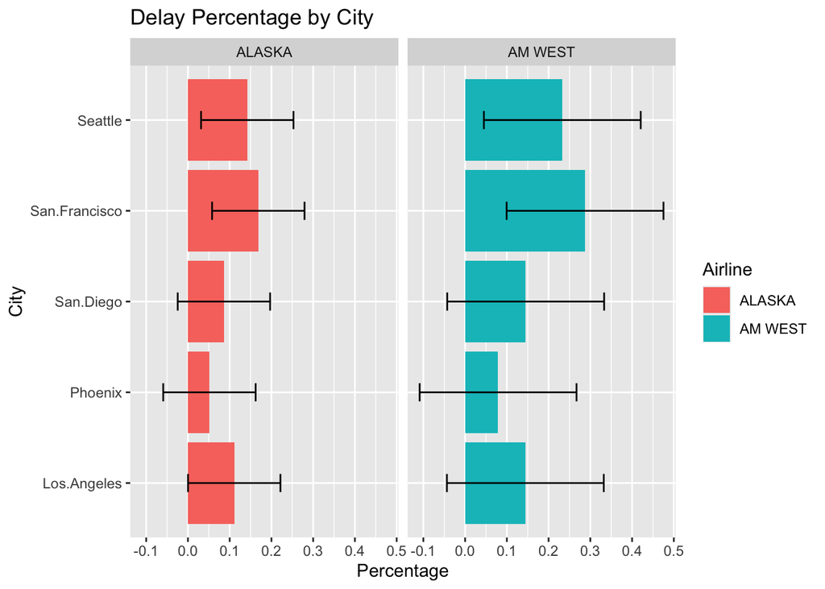

```r
ggplot(flights_analysis, aes(x = Pct_Delay, y = City, fill = Airline)) +
  facet_wrap(~ Airline) +
  geom_bar(stat = "identity") +
  geom_errorbar(aes(xmin = Pct_Delay - Pct_SD, xmax = Pct_Delay + Pct_SD), width = 0.2) +
  labs(
    title = "Delay Percentage by City",
    x = "Percentage",
    y = "City"
  )
```

### (2) Grouped by City

Here we see the cities grouped in five graphs. Each shows the delay percentages of the individual airlines.

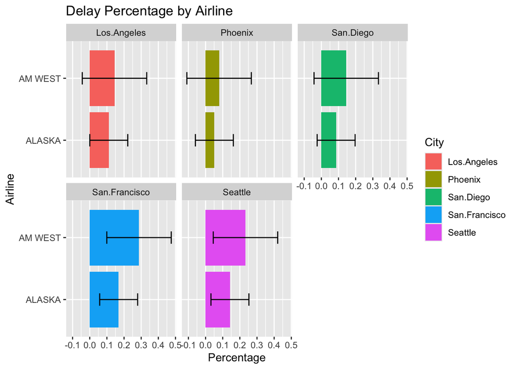

```r
ggplot(flights_analysis, aes(x = Pct_Delay, y = Airline, fill = City)) +
  facet_wrap(~ City) +
  geom_bar(stat = "identity") +
  geom_errorbar(aes(xmin = Pct_Delay - Pct_SD, xmax = Pct_Delay + Pct_SD), width = 0.2) +
  labs(
    title = "Delay Percentage by Airline",
    x = "Percentage",
    y = "Airline"
  )
```

## Overall Delay Percentage vs Airline

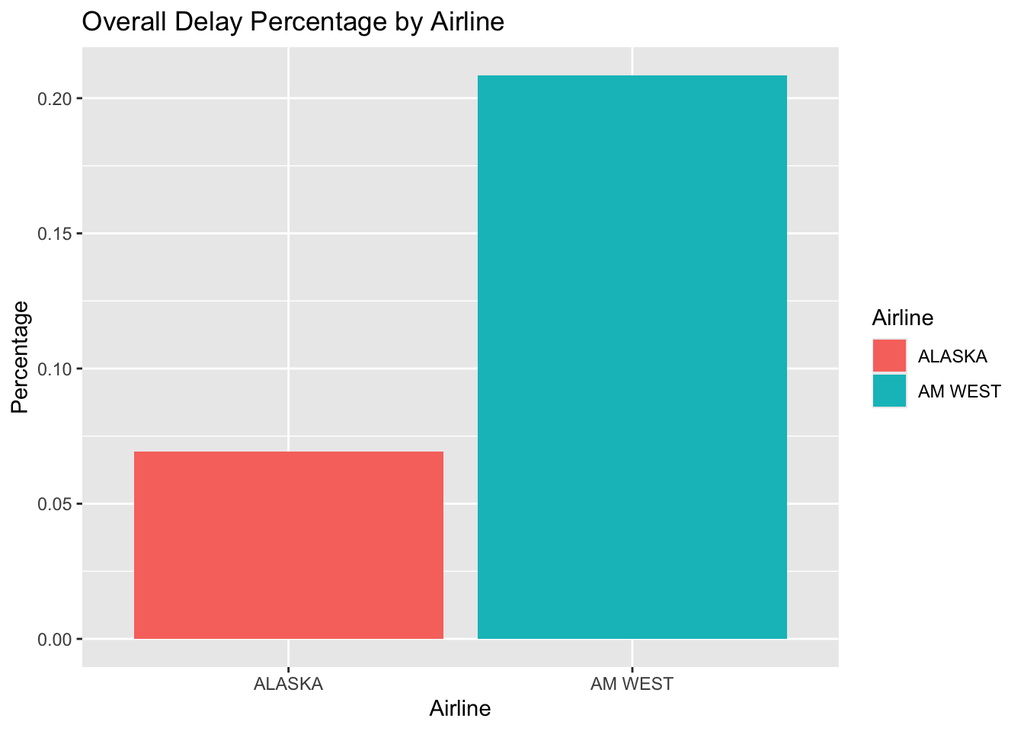

```r
del_group <- flights_analysis %>%
   group_by(Airline) %>%
   summarize(air_delay_p = mean(Airline_Delay_Pct))

ggplot(del_group, aes(x = Airline, y = air_delay_p, fill = Airline)) + geom_bar(stat = "identity") +
  labs(
    title = "Overall Delay Percentage by Airline",
    x = "Airline",
    y = "Percentage"
  )
```

## Individual Delay Percentage vs Airline (color filered by city)

### (1) Stacked (One Graph)

Here the graph is visually appealing, but may be harder to compare as the bars representing the delay percentage for each city are not properly aligned side by side.

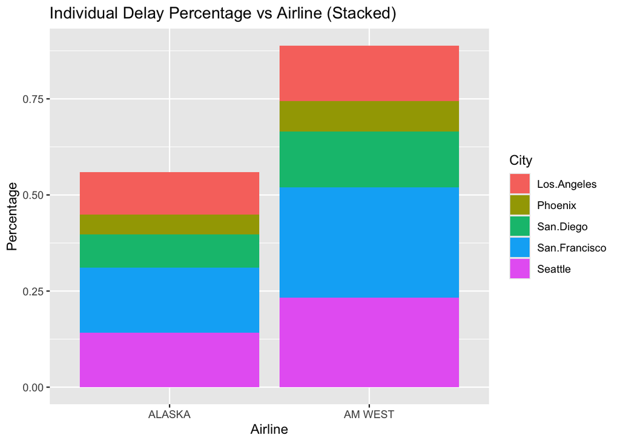

```r
ggplot(flights_analysis, aes(x = Airline, y = Pct_Delay, fill = City)) +
  geom_bar(stat = "identity", position = "stack") +
  labs(
    title = "Individual Delay Percentage vs Airline (Stacked)",
    x = "Airline",
    y = "Percentage"
  )
```

### (2) Facet Wrap (Separate Graphs)

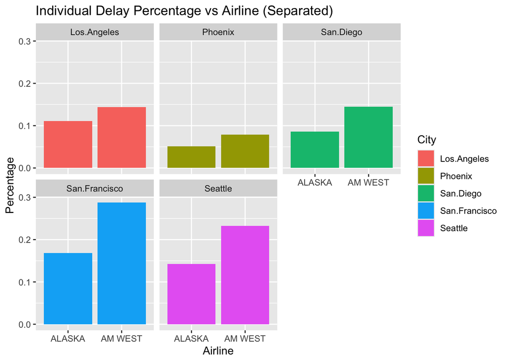

```r
ggplot(flights_analysis, aes(x = Airline, y = Pct_Delay, fill = City)) +
  facet_wrap(~ City) +
  geom_bar(stat = "identity") +
  labs(
    title = "Individual Delay Percentage vs Airline (Separated)",
    x = "Airline",
    y = "Percentage"
  )
```

## Delay Percentage vs City (color filtered by Airline)

I likewise visualized it by comparing the delay percentages of each city and filled by airline. I also swapped the axes for better readability.

### (1) Stacked (One Graph)

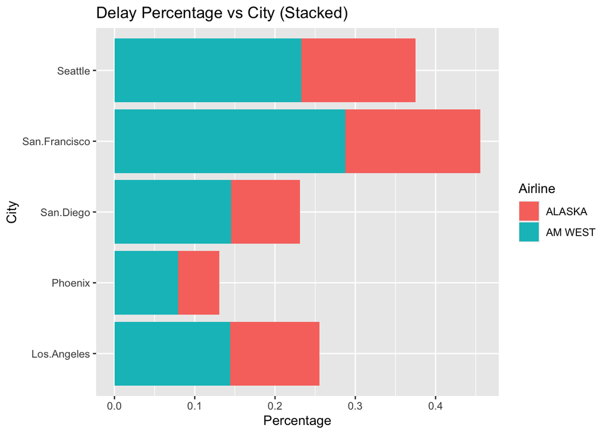

```r
ggplot(flights_analysis, aes(x = Pct_Delay, y = City, fill = Airline)) +
  geom_bar(stat = 'identity') +
  labs(
    title = "Delay Percentage vs City (Stacked)",
    x = "Percentage",
    y = "City"
  )
```

### (2) Facet Wrap (Separate Graphs)

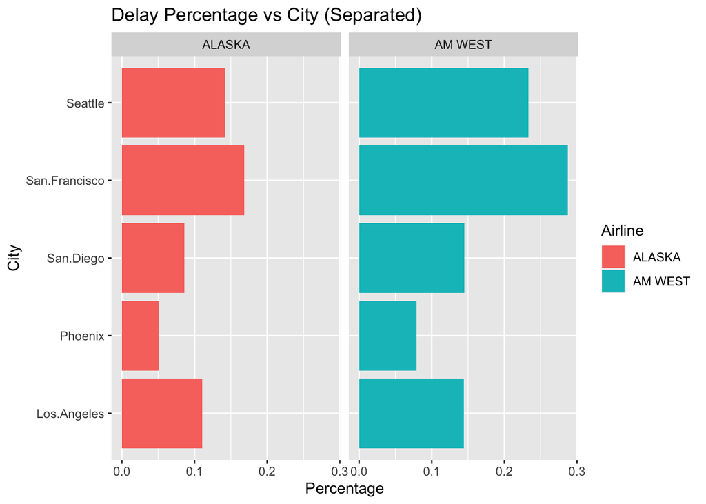

```r
ggplot(flights_analysis, aes(x = Pct_Delay, y = City, fill = Airline)) +
  facet_wrap(~ Airline) +
  geom_bar(stat = 'identity') +
  labs(
    title = "Delay Percentage vs City (Separated)",
    x = "Percentage",
    y = "City"
  )
```